# 4 t-tests: one sample and two sample

We will be covering a number of statistical tests throughout this course. Which statistical test you choose, depends on the type of experiment or study has been conducted and what type of data we have. In this chapter, we will specifically focus on applying one-sample and two-sample t-tests.

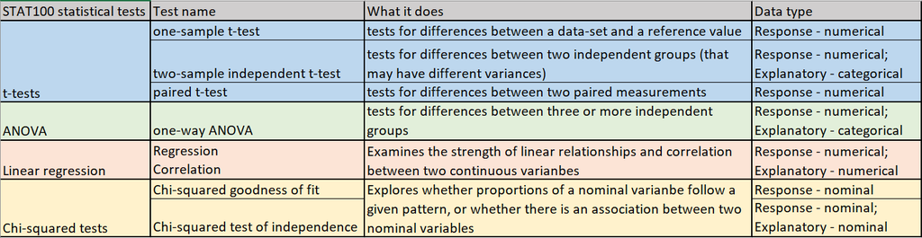

Instead of using the normal (Z) distribution, t-tests use the t-distribution. This is because t-tests are usually based on smaller sample sizes, so we need to account for extra uncertainty in the standard error and critical values. As the sample size gets bigger, the t-distribution becomes almost identical to the Z-distribution, as can be seen below.

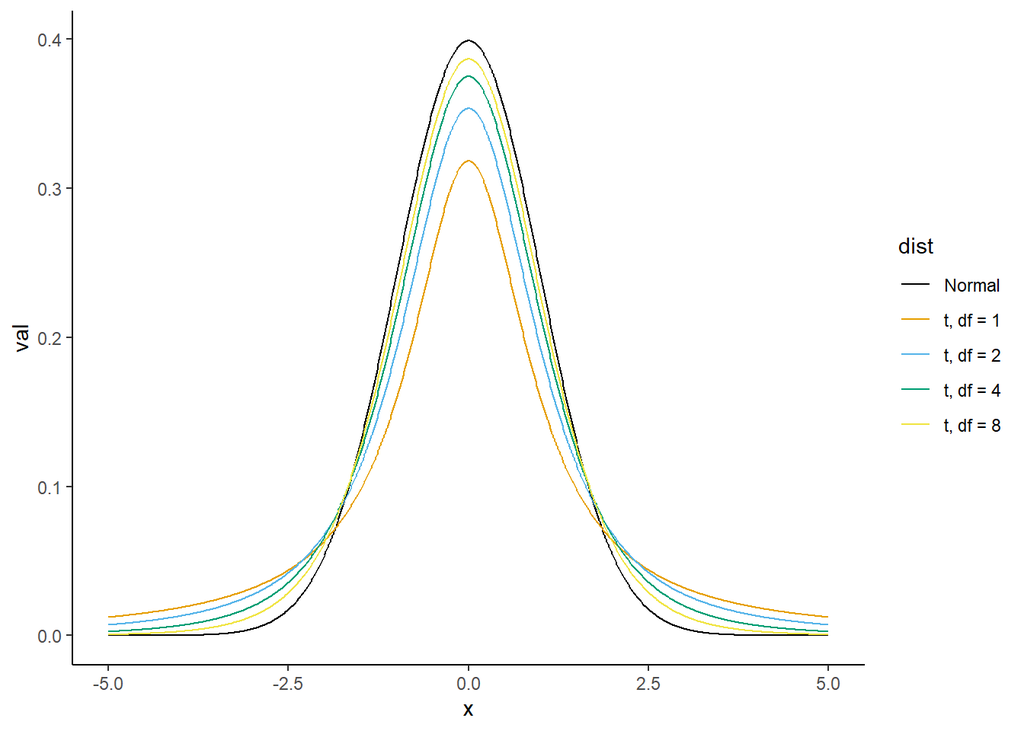

Like the previous chapter, we can use a hypothesis testing framework to approach our research questions.

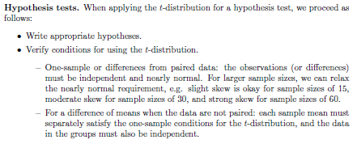

Before starting this lesson, you’ll need to download some data.

Let’s apply our skills to some real data provided by the NSW Government, and see how even the skills we have learnt in three chapters can already be useful to the real world.

[Data.NSW](https://data.nsw.gov.au/) is an open data poral with over 16,724 NSW public sector datasets to download. You can also access additional Open Data Portals listed here:

- [API.NSW](https://api.nsw.gov.au/)
- [Environmental Data Portal, SEED](https://www.seed.nsw.gov.au/)
- [HealthStats NSW](http://www.healthstats.nsw.gov.au/)
- [Transport Open Data Hub](https://opendata.transport.nsw.gov.au/)
- [NSW Bureau of Crime Statistics and Research](https://bocsar.nsw.gov.au/statistics-dashboards/open-datasets.html)
- [Spatial Collaboration Portal](https://portal.spatial.nsw.gov.au/client)
- [NSW Flood Data Portal](https://flooddata.ses.nsw.gov.au/)
- [NSW Planning Portal Spatial Viewer](https://www.planningportal.nsw.gov.au/spatialviewer/)
- [State Insurance Regulatory Authority](https://www.sira.nsw.gov.au/open-data-schemes)

# 5 **One Sample t-test**

We will look at the 2023 Early Childhood Education and Care (ECEC) survey. This survey collected responses from around 2,000 NSW parents and carers during January and February 2023, and was designed to understand which policy options families value most and what barriers affect their access to early childhood education and care. The dataset includes a broad mix of information: demographics, employment patterns, commuting times, childcare usage, costs, and satisfaction ratings. Because it contains both continuous and categorical variables, it provides a useful starting point for learning how to apply statistical tests to real-world data.

Working with real survey data can be messy, so we will go step by step and decide what needs cleaning and what does not. We’ll begin by loading the required packages and importing the dataset.

Note that if we include the argument `stringsAsFactors==TRUE`, it will convert all `str` variables to `Factor` so we won’t have to worry about our categorical variables being stored correctly.

```r
library(dplyr)
library(tidyr)
library(ggplot2)
ecec <- read.csv("Data-sets/ecec-survey-2023.csv",
                 stringsAsFactors = TRUE)
```

```r
str(ecec)
```

```
'data.frame':   2015 obs. of  678 variables:
 $ Row                 : int  1 2 3 4 5 6 7 8 9 10 ...
 $ CaseID              : int  1 2 3 4 5 6 7 8 9 10 ...
 $ RecallCode          : Factor w/ 2015 levels "0009ac95-b776-4c55-860b-94034ed92e82",..: 1378 385 1115 893 1700 590 843 524 1139 1968 ...
 $ Segment6            : Factor w/ 6 levels "Full User Other NSW",..: 4 4 1 2 5 4 3 4 2 5 ...
 $ SubmittedDate       : Factor w/ 11 levels "1-Feb-23","2-Feb-23",..: 3 3 3 3 3 3 3 3 3 4 ...
 $ ResponseTimeMinutes : num  33.37 15.59 11.81 14.05 7.35 ...
 $ BWS_BLOCK           : Factor w/ 4 levels "Block 1","Block 2",..: 4 1 3 3 4 3 3 2 3 3 ...
 $ DCE_BLOCK           : Factor w/ 9 levels "Block 1","Block 2",..: 5 9 8 9 4 5 2 7 6 1 ...
 $ SQ1                 : Factor w/ 3 levels "Female","Male",..: 2 2 1 1 1 1 2 1 2 2 ...
 $ SQ1_OTH             : logi  NA NA NA NA NA NA ...
 $ SQ2                 : int  1978 1999 1989 1977 1990 2000 2003 1978 1989 1978 ...
 $ SQ3                 : Factor w/ 2 levels "Other NSW","Sydney": 2 2 1 2 1 2 1 2 2 1 ...
 $ SQ4                 : Factor w/ 1 level "Yes": 1 1 1 1 1 1 1 1 1 1 ...
 $ SQ5                 : Factor w/ 2 levels "Yes, I am the carer/guardian and I have childcare responsibilities",..: 2 2 2 2 2 2 1 2 2 2 ...
```

[output cut: 86 more lines]

Wow! There is a lot going on. Don’t worry about the `NA` values you see. Missing data is extremely common in large surveys, and we’ll make sure to remove any NA entries that would interfere with our analysis.

You may also notice that some of the variable names aren’t very descriptive. That can happen depending on how the original survey was designed or exported. Instead of renaming everything, we’ll concentrate on the specific variables we need for our t-test. If you want to see the exact wording of the survey questions, you can refer to the questionnaire provided alongside the dataset [here](https://data.nsw.gov.au/data/dataset/d6190b60-0c23-4255-9c5f-0d1a29406a4f/resource/615ad37d-0af5-494a-8fb2-2ed85a1e1ee5/download/ecec-survey-2023_questionnaire.pdf).

## 5.1 Hypotheses

[figure not shown]

Photo by niko nguyen on Unsplash

`SQ1` represents gender, so we can go ahead and rename it to `Gender`.

`D6_1` represents the average commute time from home to work.

The average commuting time in Australia is 29 minutes, according to the [Research Report 144](https://www.bitre.gov.au/sites/default/files/rr_144.pdf) from the Department of Infrastructure and Regional Development. A useful research question to explore from here is whether the average commute from home to work for female carers in NSW is greater than this national benchmark.

Before cleaning the data, we need to set out our hypotheses.

$H_0:$ The average work commute time from home to work for female carers across NSW is not significantly different from 29 mins.

$H_A:$ The average work commute time from home to work for female carers across NSW was significantly greater than 29 mins.

We can express this in mathematical notation:

$H_0:$ $\mu = 29$

$H_A:$ $\mu > 29$

Let’s prepare the data.

For this exercise, you will need to insert the correct variable names into the code below.

**NOTE: At this stage, we will drop missing values from the dataset. If you are interested in understanding missing values and when it is appropriate to drop them, you can refer to the *Data Visualisation in R* short course. It is also recommended that you refer to** [Missing Data Imputation in R: Missing data R tutorial](https://libguides.princeton.edu/R-Missingdata) **by Princeton University on handling missing data.**

You might notice that there are 3 levels of `Gender`. We can check this:

```r
table(ecec_1$Gender)
```

```
    Female       Male Non-binary
       938        626          3
```

Since we only interested in female carers, we can filter the data. We can drop the unused labels.

```r
ecec_2 <- ecec_1 %>%
  filter(Gender %in% "Female") %>%
  droplevels()
```

Let’s take a look at the structure again.

```r
str(ecec_2)
```

```
'data.frame':   938 obs. of  2 variables:
 $ Gender      : Factor w/ 1 level "Female": 1 1 1 1 1 1 1 1 1 1 ...
 $ Work_Commute: int  65 30 900 30 15 30 15 20 45 30 ...
```

1. How many observations are there?
2. How many variables are there?
3. How many categorical variables are there?
4. How many discrete numerical variables are there?
5. How many continuous numerical variables are there?

Now we can move on to checking the conditions. To start, we’ll create a few useful plots of the home-to-work commute data. These will help us assess whether the observations can reasonably be treated as independent and whether the distribution is close enough to normal for our purposes. The normality requirement becomes less strict as the sample size grows. Slight skewness is fine around n = 15, moderate skewness is acceptable around n = 30, and even strong skewness is workable once the sample size exceeds about 60.

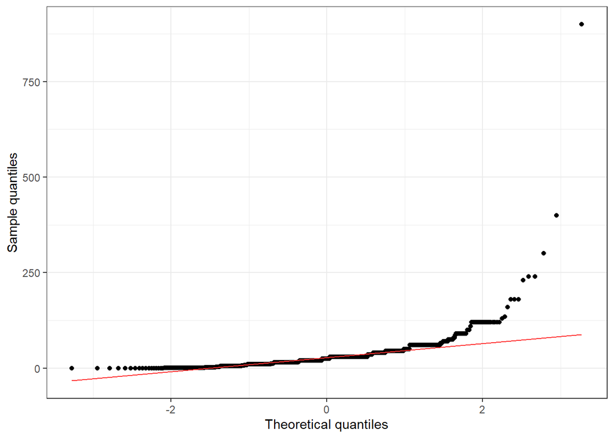

```r
ggplot(data=ecec_2, aes(sample=Work_Commute))+
  geom_qq()+ #This creates the points
  geom_qq_line(col="firebrick1")+ #this creates the line
  labs(x="Theoretical quantiles", y="Sample quantiles")+
  theme_bw()
```

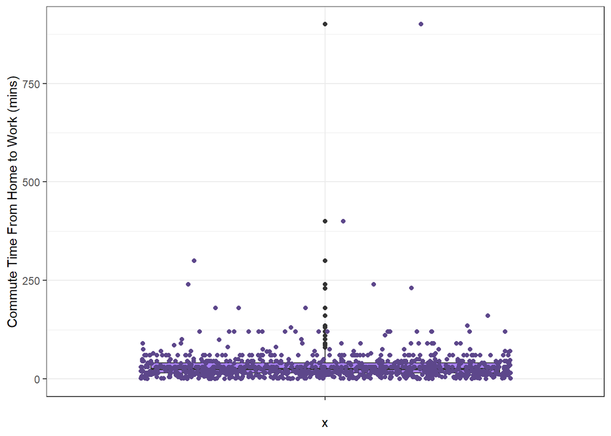

```r
ggplot(data=ecec_2, aes(y=Work_Commute, x=""))+
  geom_boxplot(fill="mediumpurple1")+
  theme_bw()+
  labs(y="Commute Time From Home to Work (mins)")+
  geom_jitter(col="mediumpurple4")
```

With 938 observations, the sample size is well above the point where normality becomes a concern. The plots show that the data are strongly right-skewed with some very large outliers. With a sample this large, the Central Limit Theorem kicks in, so the mean will still have an approximately normal sampling distribution.

For independence, we can lean on a few simple checks. Our data represent 938 female carers in NSW, which is only a tiny fraction of the overall population of female carers in the state, so we’re safely under the 10% guideline.

Because this comes from what appears to be a large, population-level survey rather, it’s reasonable to treat each person’s commute time as an independent observation.

Now that we’ve checked conditions, we can proceed with t-test. We can do this with one simple line of code:

```r
t.test(ecec_2$Work_Commute, mu = 29, alternative = "greater")
```

```
    One Sample t-test

data:  ecec_2$Work_Commute
t = 2.1482, df = 937, p-value = 0.01598
alternative hypothesis: true mean is greater than 29
95 percent confidence interval:
 29.69916      Inf
sample estimates:
mean of x
  31.9936
```

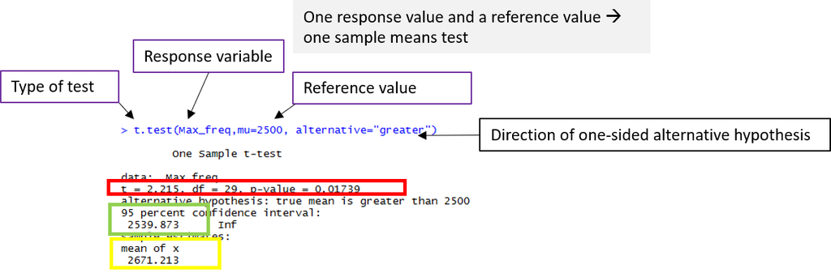

- the t-value (the statistic), the degrees of freedom (which is n-1), and the p-value: these allow us to draw our conclusion.
- the sample mean.
- and the confidence interval – though for a 1-sided test this isn’t a priority.

The p-value ($t_{937}=2.1482, p=0.0.01598$) is less than 0.05, so we have evidence to reject the null hypothesis. Therefore, there is evidence that the mean commute time from home to work for female carers in NSW is significantly greater than 29 minutes.

Note that if instead the alternative hypothesis had been Ha: μ<29 we would instead have:

```r
t.test(ecec_2$Work_Commute, mu = 29, alternative = "less")
```

```
    One Sample t-test

data:  ecec_2$Work_Commute
t = 2.1482, df = 937, p-value = 0.984
alternative hypothesis: true mean is less than 29
95 percent confidence interval:
     -Inf 34.28805
sample estimates:
mean of x
  31.9936
```

or if it was Ha: μ≠29 we would have

```r
t.test(ecec_2$Work_Commute, mu = 29, alternative = "two.sided")
```

```
    One Sample t-test

data:  ecec_2$Work_Commute
t = 2.1482, df = 937, p-value = 0.03195
alternative hypothesis: true mean is not equal to 29
95 percent confidence interval:
 29.25878 34.72843
sample estimates:
mean of x
  31.9936
```

This naturally raises other questions. For instance, because we are looking at all of NSW, it’s possible that cities like Sydney are pushing the average up. These are the kinds of patterns you could explore further with the dataset.

# 6 Two Sample t-test

For our Two Sample t-test,

`D6_1` represents the average commute time from home to work and `D6_2` represents the average commute time from work to home in minutes.

Rather than renaming both of these, we can combine them to create a single `Commute_Time` variable that reflects the total daily commute.

Before we begin cleaning the data, we need to set out our hypotheses. We are interested in whether total commute time differs between male and female carers in NSW.

Try writing the hypotheses for the two sample t test.

$H_0:$ On average, there is no difference in the total commute time to work between male and female carers in NSW.

$H_A:$ On average, there is a significant difference in the total commute time to work between males and females carers in NSW.

We can express this in mathematical notation:

$H_0:$ $\mu_{males}=\mu_{females}$

$H_A:$ $\mu_{males} \neq \mu_{females}$

With the hypotheses established, we can now move on to cleaning and preparing the dataset.

Let’s take a look at the structure of our new data set.

```r
str(ecec_new)
```

```
'data.frame':   1539 obs. of  4 variables:
 $ Gender      : Factor w/ 3 levels "Female","Male",..: 1 1 1 2 2 1 2 1 1 1 ...
 $ D6_1        : int  65 30 900 40 960 30 34 15 30 15 ...
 $ D6_2        : int  50 30 300 40 1340 30 34 25 20 20 ...
 $ Commute_Time: int  115 60 1200 80 2300 60 68 40 50 35 ...
```

You might notice that there are 3 levels of `Gender`. We can check this:

```r
table(ecec_new$Gender)
```

```
    Female       Male Non-binary
       922        614          3
```

We have 922 female respondents, 614 male respondents, and 3 Non-binary. Since we want to do a two sample t-test and we have a very low response rate from non-binary individuals, we will focus our analysis on males and females.

Try to filter the data to only male and female respondents. Don’t forget to drop unused levels. Then, check the structure of the cleaned dataset

1. How many observations are there?
2. How many variables are there?
3. How many categorical variables are there?
4. How many discrete numerical variables are there?
5. How many continuous numerical variables are there?

```r
attach(ecec_new1)
```

We can now plot the data and check conditions.

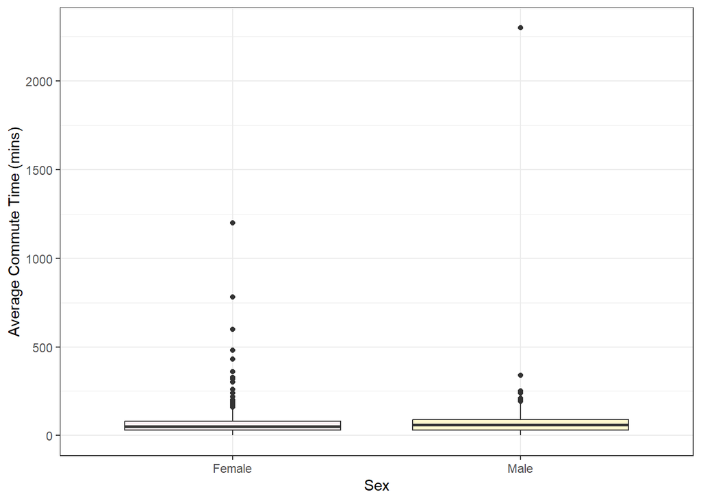

```r
ggplot(data=ecec_new1, aes(x=Gender, y=Commute_Time))+
  geom_boxplot(fill = c("lavenderblush1", "lemonchiffon"))+
  labs(x="Sex", y="Average Commute Time (mins)")+
  theme_bw()
```

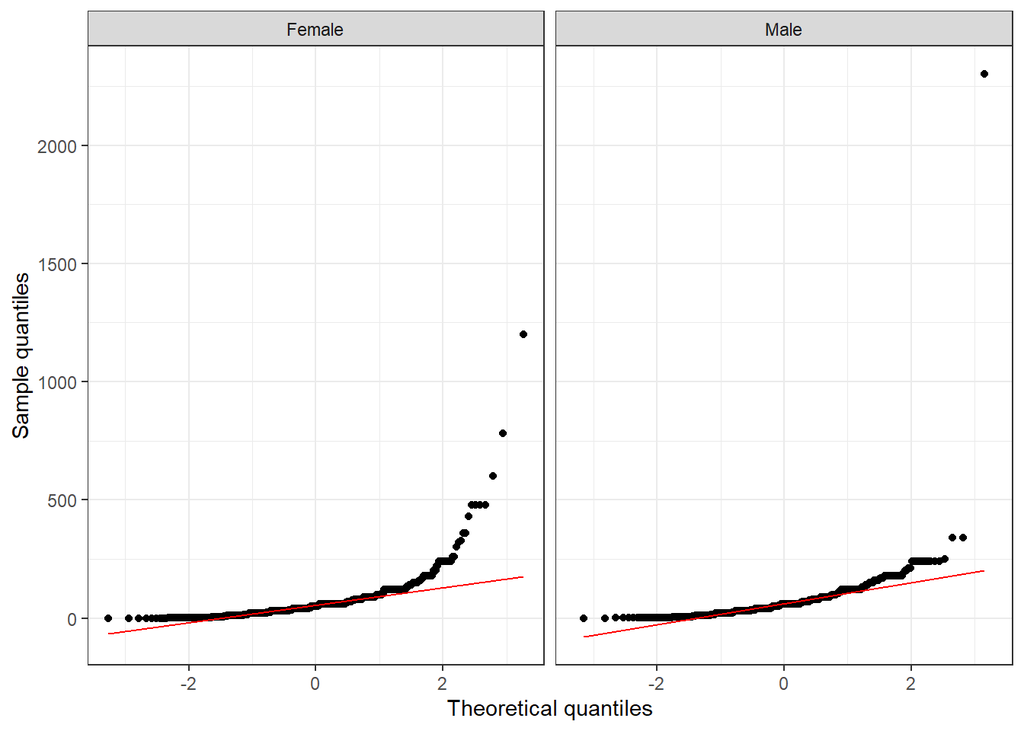

```r
ggplot(ecec_new1, aes(sample=Commute_Time))+
  geom_qq()+
  geom_qq_line(col="red")+
  labs(x="Theoretical quantiles", y="Sample quantiles")+
  theme_bw()+
  facet_wrap(~Gender)
```

We can see that there are a lot of outliers for both females and males. Even so, the main part of each boxplot looks fairly similar in shape, so there’s no obvious imbalance between the groups.

Looking at the Q-Q plots, there is some deviation in the upper tail for females, and males shows some slight deviation as well with one extreme value. However, most of the points still fall close to the line, so we can argue that the data look approximately normal in the middle of the distribution even if the tails stretch out.

A bit of skewness is fine with big samples. Slight skewness is usually ok with sample sizes around 15, moderate skewness with 30, and even strong skewness becomes acceptable once you get past about 60. Since our sample sizes are very large (female: 922 and male: 614), the t-test can handle the skewness without much trouble.

We can calculate the point estimates, and standard errors. A convenient way to do this across groups is:

```r
aggregate(Commute_Time~Gender, FUN=mean)
```

```
  Gender Commute_Time
1 Female     64.65835
2   Male     70.60912
```

```r
aggregate(Commute_Time~Gender, FUN=sd)
```

```
  Gender Commute_Time
1 Female     75.21018
2   Male    104.84408
```

```r
aggregate(Commute_Time~Gender, FUN=length)
```

```
  Gender Commute_Time
1 Female          922
2   Male          614
```

Now we can perform the test.

```r
t.test(Commute_Time ~ Gender)
```

```
    Welch Two Sample t-test

data:  Commute_Time by Gender
t = -1.2137, df = 1025, p-value = 0.2251
alternative hypothesis: true difference in means between group Female and group Male is not equal to 0
95 percent confidence interval:
 -15.571520   3.669982
sample estimates:
mean in group Female   mean in group Male
            64.65835             70.60912
```

The p-value ($t_{1025}=-1.2137, p=0.2251$) is greater than 0.05, so we fail to reject the null hypothesis. Therefore, there is no difference in average commute time to work between males and females carers across NSW.

With 95% confidence, the average commute time for females could be about 16 minutes less or about 4 minutes more than the average for males. Because this range includes zero, it doesn’t point to a clear difference between the two groups.